# Técnicas para imputación datos faltantes - AMES Housing Dataset

R. J. Serrano

2023-10-10

## AMES Housing Dataset

El dataset titulado ‘AMES Housing’ contiene información proveniente de la oficina del evaludador de Ames utilizada para calcular los valores tasados de propiedades residenciales individuales vendidas en Ames, IA de 2006 a 2010.

Referencia:

De Cock, D. (2011). “Ames, Iowa: Alternative to the Boston Housing Data as an End of Semester Regression Project,” Journal of Statistics Education, Volume 19, Number 3.

Para propósitos de este charla, vamos a seleccionar un subconjunto de variables del dataset original.

```r
ames <- read_csv('../data/ames.csv') %>%
     janitor::clean_names() %>%
     select(sale_price, lot_frontage, lot_area, alley, lot_shape,
            gr_liv_area, overall_qual, garage_type, garage_cars,
            screen_porch, fence, yr_sold, mo_sold)

ames
```

| sale_price | lot_frontage | lot_area | alley | lot_shape | gr_liv_area | overall_qual | garage_type | garage_cars | screen_porch | fence | yr_sold | mo_sold |
| --- | --- | --- | --- | --- | --- | --- | --- | --- | --- | --- | --- | --- |
| 215000 | 141 | 31770 | NA | IR1 | 1656 | 6 | Attchd | 2 | 0 | NA | 2010 | 5 |
| 105000 | 80 | 11622 | NA | Reg | 896 | 5 | Attchd | 1 | 120 | MnPrv | 2010 | 6 |
| 172000 | 81 | 14267 | NA | IR1 | 1329 | 6 | Attchd | 1 | 0 | NA | 2010 | 6 |
| 244000 | 93 | 11160 | NA | Reg | 2110 | 7 | Attchd | 2 | 0 | NA | 2010 | 4 |
| 189900 | 74 | 13830 | NA | IR1 | 1629 | 5 | Attchd | 2 | 0 | MnPrv | 2010 | 3 |
| 195500 | 78 | 9978 | NA | IR1 | 1604 | 6 | Attchd | 2 | 0 | NA | 2010 | 6 |
| 213500 | 41 | 4920 | NA | Reg | 1338 | 8 | Attchd | 2 | 0 | NA | 2010 | 4 |
| 191500 | 43 | 5005 | NA | IR1 | 1280 | 8 | Attchd | 2 | 144 | NA | 2010 | 1 |
| 236500 | 39 | 5389 | NA | IR1 | 1616 | 8 | Attchd | 2 | 0 | NA | 2010 | 3 |
| 189000 | 60 | 7500 | NA | Reg | 1804 | 7 | Attchd | 2 | 0 | NA | 2010 | 6 |

[output cut: 2920 more lines]

## EDA

Dimensiones del dataset

```r
dim(ames)
```

```
## [1] 2930   13
```

¿Cuál es el porciento de datos faltantes por variable?

```r
ames %>%
     map_df(~ mean(is.na(.)) * 100) %>%
     select_if(colSums(.) > 0)
```

| lot_frontage | alley | garage_type | garage_cars | fence |
| --- | --- | --- | --- | --- |
| 16.72355 | 93.24232 | 5.358362 | 0.03412969 | 80.47782 |

```r
library(skimr)
skim_without_charts(ames)
```

```
## ── Data Summary ────────────────────────
##                            Values
## Name                       ames
## Number of rows             2930
## Number of columns          13
## _______________________
## Column type frequency:
##   character                4
##   numeric                  9
## ________________________
## Group variables            None
##
## ── Variable type: character ────────────────────────────────────────────────────
##   skim_variable n_missing complete_rate min max empty n_unique whitespace
## 1 alley              2732        0.0676   4   4     0        2          0
## 2 lot_shape             0        1        3   3     0        4          0
## 3 garage_type         157        0.946    6   7     0        6          0
## 4 fence              2358        0.195    4   5     0        4          0
##
## ── Variable type: numeric ──────────────────────────────────────────────────────
##   skim_variable n_missing complete_rate      mean        sd    p0     p25
## 1 sale_price            0         1     180796.   79887.    12789 129500
## 2 lot_frontage        490         0.833     69.2     23.4      21     58
## 3 lot_area              0         1      10148.    7880.     1300   7440.
## 4 gr_liv_area           0         1       1500.     506.      334   1126
## 5 overall_qual          0         1          6.09     1.41      1      5
## 6 garage_cars           1         1.00       1.77     0.761     0      1
## 7 screen_porch          0         1         16.0     56.1       0      0
## 8 yr_sold               0         1       2008.       1.32   2006   2007
## 9 mo_sold               0         1          6.22     2.71      1      4
##       p50     p75   p100
## 1 160000  213500  755000
## 2     68      80     313
## 3   9436.  11555. 215245
## 4   1442    1743.   5642
## 5      6       7      10
## 6      2       2       5
## 7      0       0     576
## 8   2008    2009    2010
## 9      6       8      12
```

Visualizar los datos faltantes

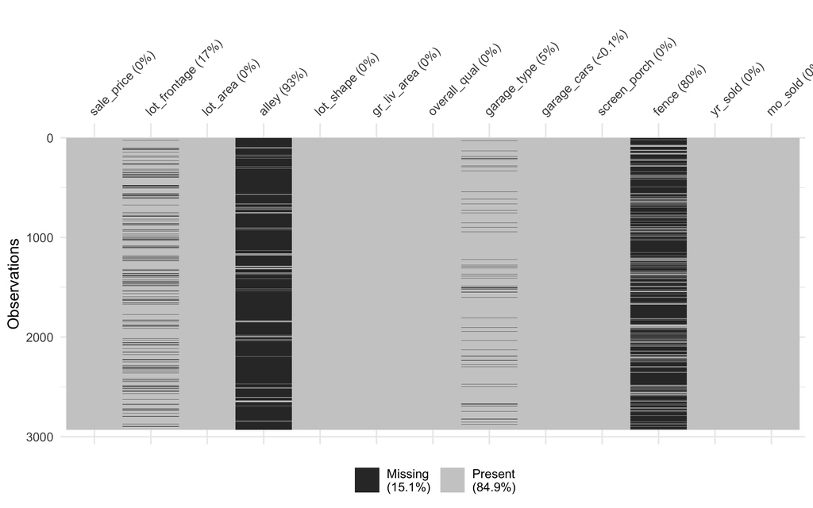

```r
vis_miss(ames)
```

¿Qué sucede si eliminamos las filas (rows) donde aparecen al menos un data faltante?

```r
ames %>%
     drop_na() %>%
     dim()
```

```
## [1] 31 13
```

Antes de continuar, debemos investigar si el dataset contiene metadata que nos pueda ayudar a entender el significado de los datos faltantes. Por ejemplo:

```r
ames %>%
     count(alley)
```

| alley | n |
| --- | --- |
| Grvl | 120 |
| Pave | 78 |
| NA | 2732 |

En la documentación, encontramos que `NA` en la variable `alley` significa ‘No alley access’. Por lo tanto, podemos asignar la etiqueta `None` a los datos faltantes en la variable `alley`.

```r
ames_imp_1 <- ames %>%
     mutate(alley = alley %>% replace_na(., 'None'))

ames_imp_1 %>%
     count(alley)
```

| alley | n |
| --- | --- |
| Grvl | 120 |
| None | 2732 |
| Pave | 78 |

Utilizamos la misma técnica para las variables `garage_type` y `fence`

```r
ames_imp_2 <- ames_imp_1 %>%
     mutate(garage_type = garage_type %>% replace_na(., 'None'),
            fence = fence %>% replace_na(., 'None')
            )

ames_imp_2 %>%
     count(garage_type)
```

| garage_type | n |
| --- | --- |
| 2Types | 23 |
| Attchd | 1731 |
| Basment | 36 |
| BuiltIn | 186 |
| CarPort | 15 |
| Detchd | 782 |
| None | 157 |

```r
ames_imp_2 %>%
     count(fence)
```

| fence | n |
| --- | --- |
| GdPrv | 118 |
| GdWo | 112 |
| MnPrv | 330 |
| MnWw | 12 |
| None | 2358 |

En el caso de la variable `garage_cars`, solo tenemos una observación con datos faltantes. Vamos a verificar esa observación.

```r
ames_imp_2 %>%
     filter(is.na(garage_cars))
```

| sale_price | lot_frontage | lot_area | alley | lot_shape | gr_liv_area | overall_qual | garage_type | garage_cars | screen_porch | fence | yr_sold | mo_sold |
| --- | --- | --- | --- | --- | --- | --- | --- | --- | --- | --- | --- | --- |
| 150909 | 50 | 9060 | None | Reg | 1828 | 5 | Detchd | NA | 0 | MnPrv | 2007 | 3 |

No tenemos una idea clara, examinando las variables de esta observación, de una valor razonable para imputar la capacidad de vehículos en el garaje. Por lo tanto, una solución es descartar la observación.

```r
ames_imp_3 <- ames_imp_2 %>%
     drop_na(garage_cars)
```

Solo nos queda una variable con datos faltantes `lot_frontage`. Es una variable númerica continua. Debemos visualizar esta variable con un histograma.

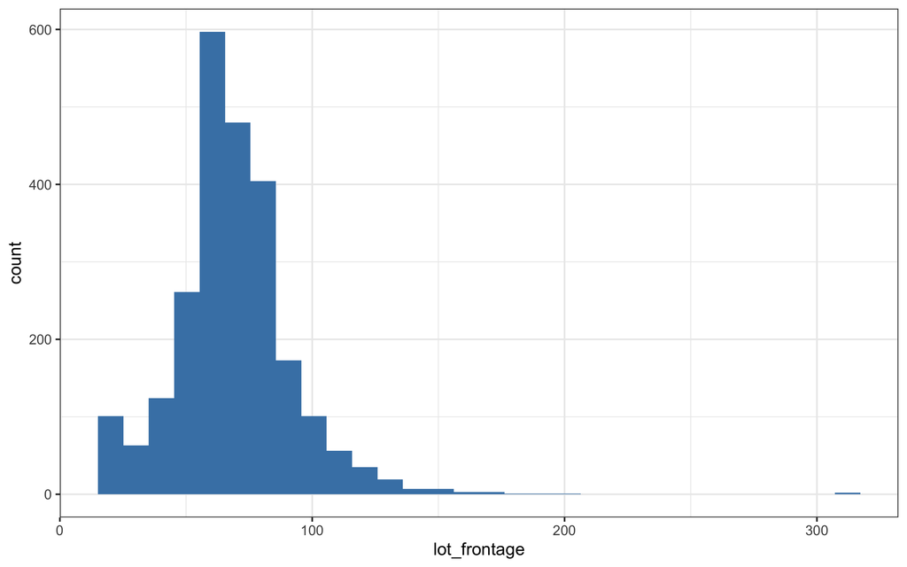

```r
ames_imp_3 %>%
     ggplot(aes(lot_frontage)) +
     geom_histogram(fill = 'steelblue')
```

Vamos a experimentar con la imputación de `lot_frontage` usando la mediana.

```r
ames_imp_4 <- ames_imp_3 %>%
     mutate(across(lot_frontage, ~replace_na(., median(., na.rm = TRUE))))

skimr::skim_without_charts(ames_imp_4)
```

```
## ── Data Summary ────────────────────────
##                            Values
## Name                       ames_imp_4
## Number of rows             2929
## Number of columns          13
## _______________________
## Column type frequency:
##   character                4
##   numeric                  9
## ________________________
## Group variables            None
##
## ── Variable type: character ────────────────────────────────────────────────────
##   skim_variable n_missing complete_rate min max empty n_unique whitespace
## 1 alley                 0             1   4   4     0        3          0
## 2 lot_shape             0             1   3   3     0        4          0
## 3 garage_type           0             1   4   7     0        7          0
## 4 fence                 0             1   4   5     0        5          0
##
## ── Variable type: numeric ──────────────────────────────────────────────────────
##   skim_variable n_missing complete_rate      mean        sd    p0    p25    p50
## 1 sale_price            0             1 180806.   79898.    12789 129500 160000
## 2 lot_frontage          0             1     69.0     21.3      21     60     68
## 3 lot_area              0             1  10148.    7881.     1300   7440   9439
## 4 gr_liv_area           0             1   1500.     506.      334   1126   1442
## 5 overall_qual          0             1      6.10     1.41      1      5      6
## 6 garage_cars           0             1      1.77     0.761     0      1      2
## 7 screen_porch          0             1     16.0     56.1       0      0      0
## 8 yr_sold               0             1   2008.       1.32   2006   2007   2008
## 9 mo_sold               0             1      6.22     2.71      1      4      6
##      p75   p100
## 1 213500 755000
## 2     78    313
## 3  11556 215245
## 4   1742   5642
## 5      7     10
## 6      2      5
## 7      0    576
## 8   2009   2010
## 9      8     12
```

Vamos a evaluar la calidad de la imputación de esta variable.

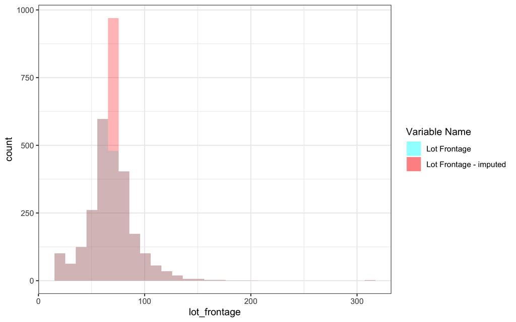

```r
ames_imp_4 %>%
     rename(lot_frontage_imp = lot_frontage) %>%
     add_column(lot_frontage = ames_imp_3$lot_frontage) %>%
     ggplot() +
     geom_histogram(aes(lot_frontage, fill = "Lot Frontage"), alpha = 0.3) +
     geom_histogram(aes(lot_frontage_imp, fill = "Lot Frontage - imputed"),
                    alpha = 0.3) +
     scale_fill_manual(values = c("cyan", "red")) +
     labs(fill = "Variable Name")
```

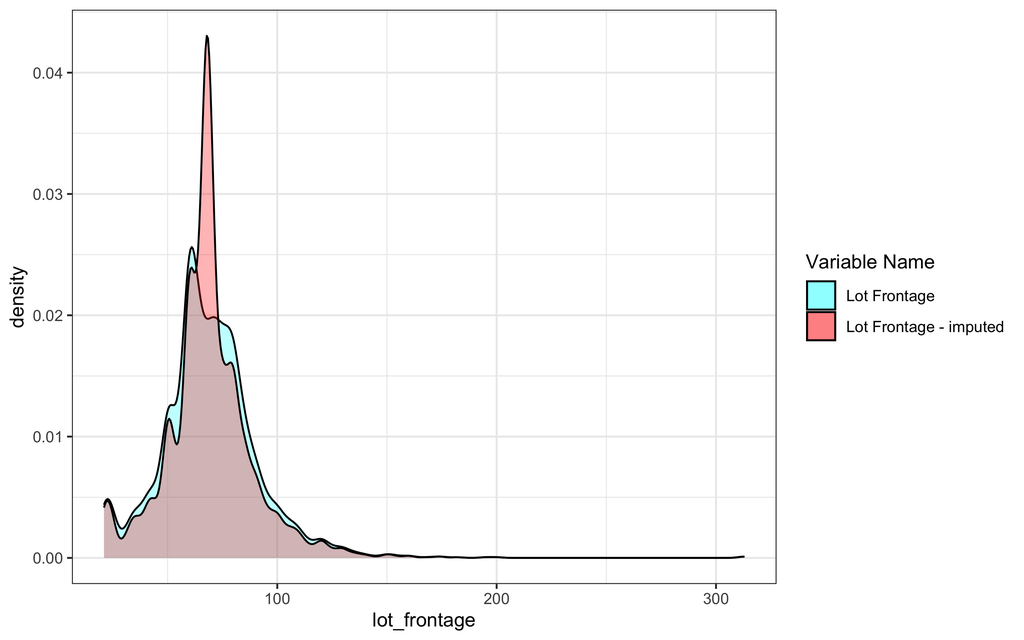

```r
ames_imp_4 %>%
     rename(lot_frontage_imp = lot_frontage) %>%
     add_column(lot_frontage = ames_imp_3$lot_frontage) %>%
     ggplot() +
     geom_density(aes(lot_frontage, fill = "Lot Frontage"), alpha = 0.3) +
     geom_density(aes(lot_frontage_imp, fill = "Lot Frontage - imputed"),
                    alpha = 0.3) +
     scale_fill_manual(values = c("cyan", "red")) +
     labs(fill = "Variable Name")
```

Podemos observar que la imputación usando la mediana provoca un pico que no está presente en los datos originales.

Alternativa: utilizar métodos de regresión/kNN/randomforest que simulen la distribución original de los datos.

```r
# kNN
ames_imp_5 <- kNN(ames_imp_3, variable = "lot_frontage")

skimr::skim_without_charts(ames_imp_5)
```

```
## ── Data Summary ────────────────────────
##                            Values
## Name                       ames_imp_5
## Number of rows             2929
## Number of columns          14
## _______________________
## Column type frequency:
##   character                4
##   logical                  1
##   numeric                  9
## ________________________
## Group variables            None
##
## ── Variable type: character ────────────────────────────────────────────────────
##   skim_variable n_missing complete_rate min max empty n_unique whitespace
## 1 alley                 0             1   4   4     0        3          0
## 2 lot_shape             0             1   3   3     0        4          0
## 3 garage_type           0             1   4   7     0        7          0
## 4 fence                 0             1   4   5     0        5          0
##
## ── Variable type: logical ──────────────────────────────────────────────────────
##   skim_variable    n_missing complete_rate  mean count
## 1 lot_frontage_imp         0             1 0.167 FAL: 2439, TRU: 490
##
## ── Variable type: numeric ──────────────────────────────────────────────────────
##   skim_variable n_missing complete_rate      mean        sd    p0    p25    p50
## 1 sale_price            0             1 180806.   79898.    12789 129500 160000
## 2 lot_frontage          0             1     69.3     21.9      21     60     69
## 3 lot_area              0             1  10148.    7881.     1300   7440   9439
## 4 gr_liv_area           0             1   1500.     506.      334   1126   1442
## 5 overall_qual          0             1      6.10     1.41      1      5      6
## 6 garage_cars           0             1      1.77     0.761     0      1      2
## 7 screen_porch          0             1     16.0     56.1       0      0      0
## 8 yr_sold               0             1   2008.       1.32   2006   2007   2008
## 9 mo_sold               0             1      6.22     2.71      1      4      6
##      p75   p100
## 1 213500 755000
## 2     80    313
## 3  11556 215245
## 4   1742   5642
## 5      7     10
## 6      2      5
## 7      0    576
## 8   2009   2010
## 9      8     12
```

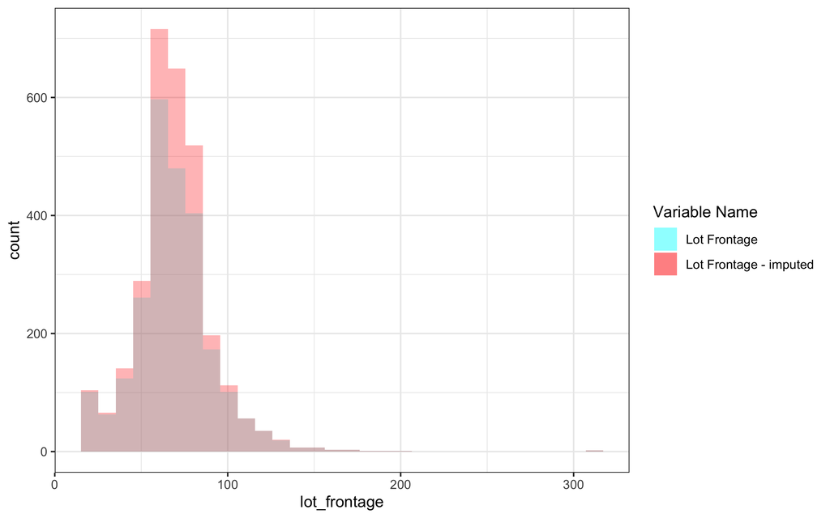

```r
ames_imp_5 %>%
     select(-lot_frontage_imp) %>%
     rename(lot_frontage_imp = lot_frontage) %>%
     add_column(lot_frontage = ames_imp_3$lot_frontage) %>%
     ggplot() +
     geom_histogram(aes(lot_frontage, fill = "Lot Frontage"), alpha = 0.3) +
     geom_histogram(aes(lot_frontage_imp, fill = "Lot Frontage - imputed"),
                    alpha = 0.3) +
     scale_fill_manual(values = c("cyan", "red")) +
     labs(fill = "Variable Name")
```

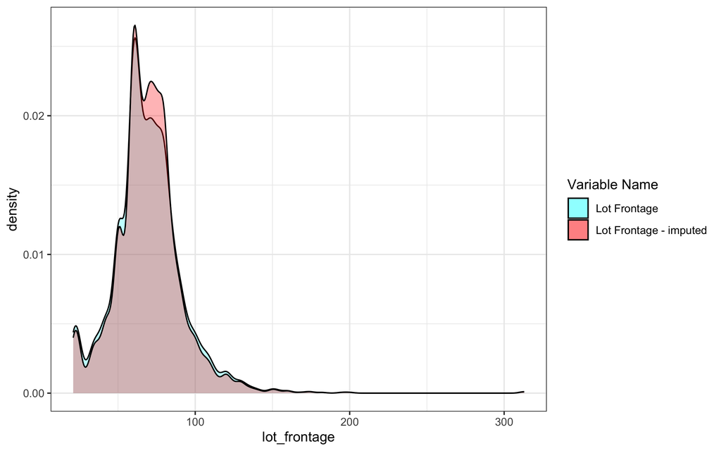

```r
ames_imp_5 %>%
     select(-lot_frontage_imp) %>%
     rename(lot_frontage_imp = lot_frontage) %>%
     add_column(lot_frontage = ames_imp_3$lot_frontage) %>%
     ggplot() +
     geom_density(aes(lot_frontage, fill = "Lot Frontage"), alpha = 0.3) +
     geom_density(aes(lot_frontage_imp, fill = "Lot Frontage - imputed"),
                    alpha = 0.3) +
     scale_fill_manual(values = c("cyan", "red")) +
     labs(fill = "Variable Name")
```

## Conclusiones

1. Visualizar las variables y el porcentaje de datos faltantes.
2. Investigar la documentación y elaboración de los datos.
3. Utilización de técnicas que reflejen un análisis riguroso y objetivo para la imputación de los datos.
4. Verificar si la imputación realizada no altera significativamente el perfil original de los datos.